# ANALISI-SERIE-STORICHE

Sara

12 gennaio 2026

## Introduzione

richiamare le librerie utili

caricare il DB

```r
dirdata<-setwd("/Users/sarac/Desktop/lavori_uni/Rstudio")
load(paste0(dirdata,"/dataset_08.Rdata"))
class(y)
```

```
## [1] "ts"
```

La tipologia di dato è gia di tipo time series, quindi non dobbiamo fare nessuno step successivo per modificarla.

**Grafico serie storica:**

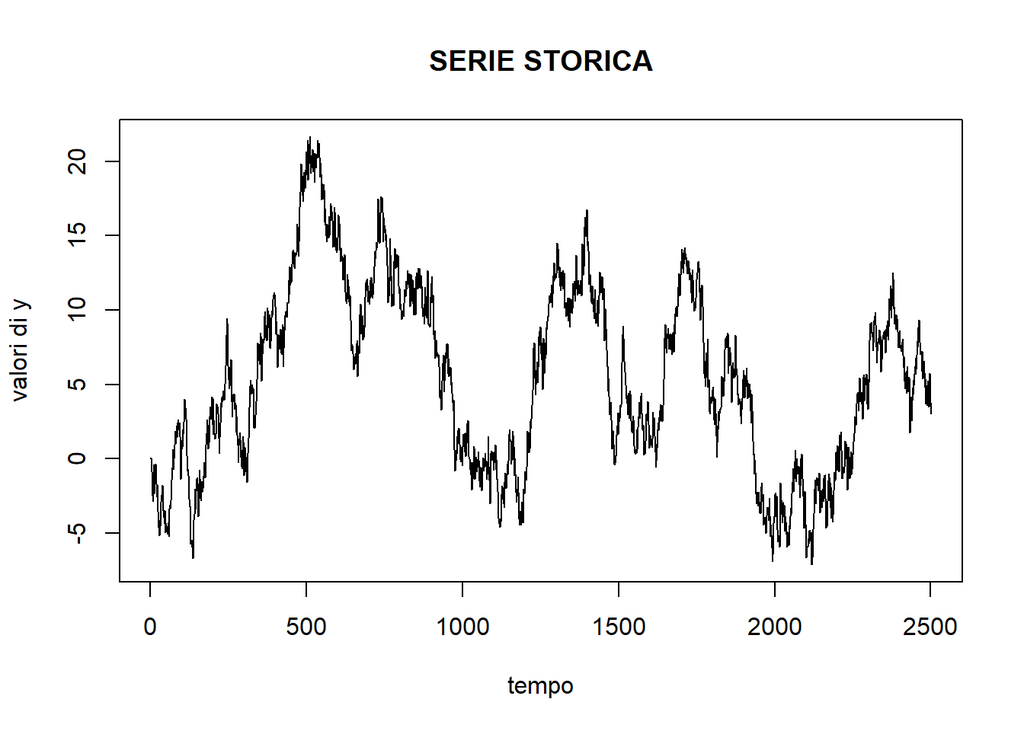

```r
plot(y, main="SERIE STORICA", xlab="tempo", ylab="valori di y" )
```

il grafico mostra un andamento che non è tipico di una serie storica stazionaria. In più, non sembra che la serie abbia un andamento creascente, che faccia pensare a un trend.

**Estrazione delle informazioni base:**

```r
summary(y)
```

```
##    Min. 1st Qu.  Median    Mean 3rd Qu.    Max.
## -7.1090  0.2207  5.0704  5.3988 10.3457 21.6589
```

```r
round(basicStats(y),digits=3)
```

```
##                     y
## nobs         2501.000
## NAs             0.000
## Minimum        -7.109
## Maximum        21.659
## 1. Quartile     0.221
## 3. Quartile    10.346
## Mean            5.399
## Median          5.070
## Sum         13502.380
## SE Mean         0.124
## LCL Mean        5.155
## UCL Mean        5.642
## Variance       38.532
## Stdev           6.207
## Skewness        0.215
## Kurtosis       -0.710
```

*verifica se il processo è integrato tramite i grafici di autocorrezione:*

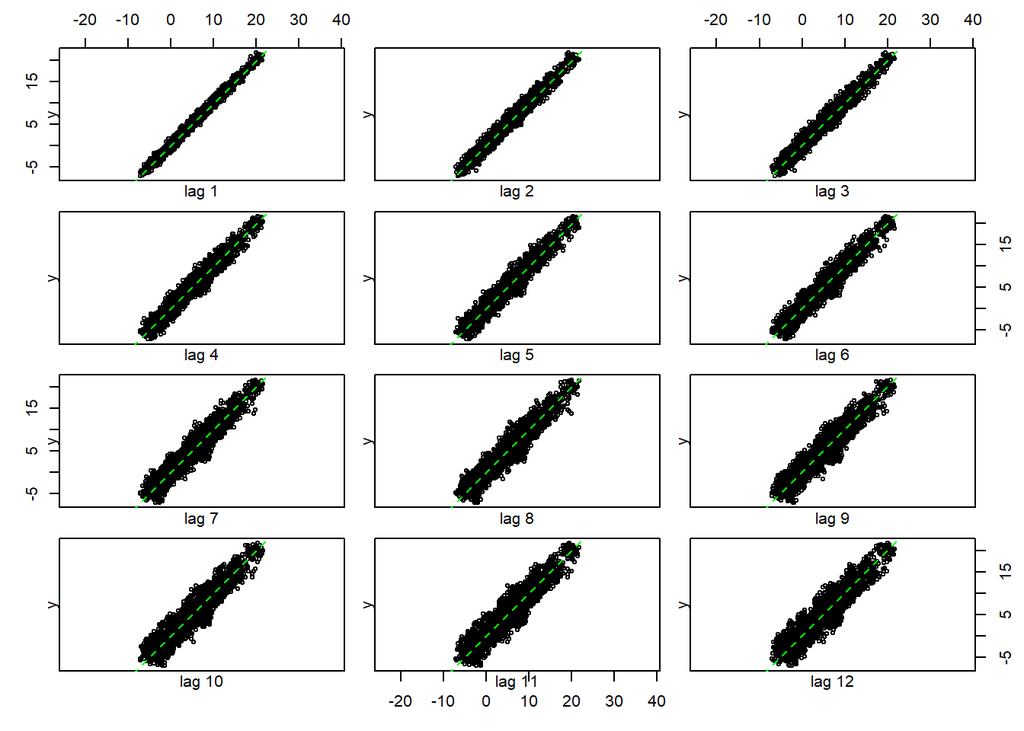

```r
lag.plot(y, lag=12, diag.col = "green", type="p", do.lines = F, labels =F )
```

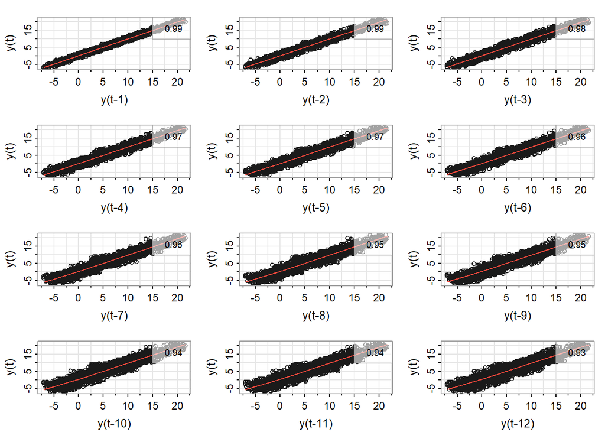

```r
lag1.plot(y,12)
```

Entrambi grafici mostrano un’autocorrelazione molto evidente, coerente con l’ipotesi di assenza di stazionarietà osservata nel grafico sopra.

*Analisi di autocorrelazione globale e parziale:*

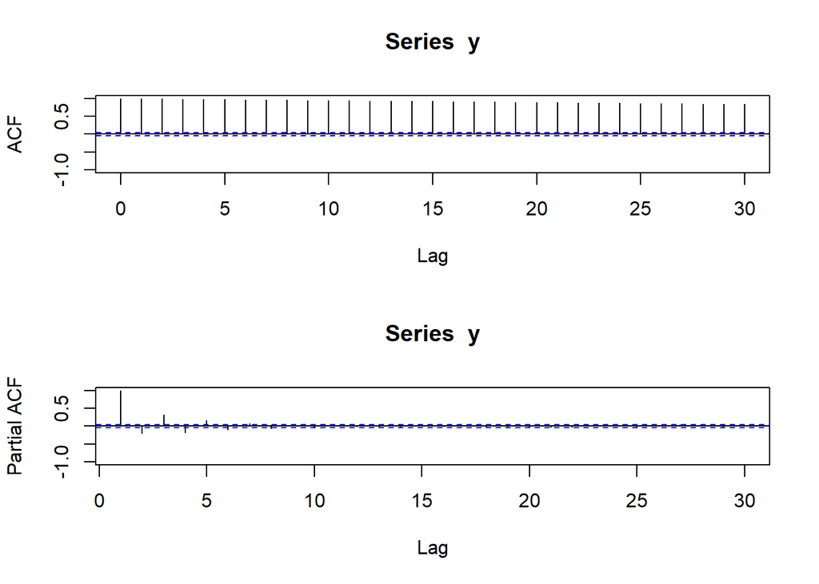

```r
op=par(mfrow=c(2,1))
acf(y,lag.max=30,ylim=c(-1,1))
pacf(y,lag.max=30,ylim=c(-1,1))
```

Guardando ai correlogrammi, notiamo ACF è persistente nel tempo e positiva, quindi , conferma l’ipotesi di autocorrelazione e questo ci può far pensare a un processo integrato di ordine 1.

la PACF decresce,invece,in valore assoluto.

## Identificazione del modello:

Andiamo a sottoporre la serie storica analizzata a una verifica della sua stazionarietà, tramite l’Augmented Dickey-Fuller test, il quale è basato su tre alternative “trend”, “drift” e “none” .

Non possiamo considerare il test che considera il trend, poichè non sembra risultare dall’andamento della serie storica.

Ci aspettiamo che i valori trovati tramite il test diano evidenza empirica sufficiente per rifiutare H0 (l’ipotesi di unit root e cioè di assenza di stazionarietà).

```r
summary(ur.df(y = y, type = 'none', selectlags = 'AIC'))
```

```
##
## ###############################################
## # Augmented Dickey-Fuller Test Unit Root Test #
## ###############################################
##
## Test regression none
##
##
## Call:
## lm(formula = z.diff ~ z.lag.1 - 1 + z.diff.lag)
##
## Residuals:
##      Min       1Q   Median       3Q      Max
## -2.04845 -0.42156  0.04313  0.46697  2.53477
##
## Coefficients:
##             Estimate Std. Error t value Pr(>|t|)
## z.lag.1    -0.004033   0.001613  -2.501   0.0125 *
## z.diff.lag  0.198757   0.019619  10.131   <2e-16 ***
## ---
## Signif. codes:  0 '***' 0.001 '**' 0.01 '*' 0.05 '.' 0.1 ' ' 1
##
## Residual standard error: 0.6628 on 2497 degrees of freedom
## Multiple R-squared:  0.04108,    Adjusted R-squared:  0.04031
## F-statistic: 53.48 on 2 and 2497 DF,  p-value: < 2.2e-16
##
##
## Value of test-statistic is: -2.5008
##
## Critical values for test statistics:
##       1pct  5pct 10pct
## tau1 -2.58 -1.95 -1.62
```

*H0:gamma=0 unit root non stazionario* *H1:gamma<0 stazionario*

in questo caso per i livelli di significatività del 5% e 10% si rifiuta l’ipotesi H0 di unit root e il processo è considerato stazionario. Invece, per livello di significatività dell’1% non abbiamo abbastanza evidenza empirica per rifiutare H0.

Poiché non abbiamo ottenuto un risultato coerente, passiamo al secondo step e consideriamo un processo con drift, cercando di capire se la situazione migliora.

```r
summary(ur.df(y = y, type = 'drift', selectlags = 'AIC'))
```

```
##
## ###############################################
## # Augmented Dickey-Fuller Test Unit Root Test #
## ###############################################
##
## Test regression drift
##
##
## Call:
## lm(formula = z.diff ~ z.lag.1 + 1 + z.diff.lag)
##
## Residuals:
##      Min       1Q   Median       3Q      Max
## -2.09394 -0.44754  0.02117  0.44508  2.51179
##
## Coefficients:
##              Estimate Std. Error t value Pr(>|t|)
## (Intercept)  0.039851   0.017570   2.268 0.023406 *
## z.lag.1     -0.007217   0.002137  -3.377 0.000744 ***
## z.diff.lag   0.200236   0.019614  10.209  < 2e-16 ***
## ---
## Signif. codes:  0 '***' 0.001 '**' 0.01 '*' 0.05 '.' 0.1 ' ' 1
##
## Residual standard error: 0.6622 on 2496 degrees of freedom
## Multiple R-squared:  0.04305,    Adjusted R-squared:  0.04228
## F-statistic: 56.14 on 2 and 2496 DF,  p-value: < 2.2e-16
##
##
## Value of test-statistic is: -3.377 5.7043
##
## Critical values for test statistics:
##       1pct  5pct 10pct
## tau2 -3.43 -2.86 -2.57
## phi1  6.43  4.59  3.78
```

*H0:gamma=0 unit root non stazionario* *H1:gamma<0 stazionario*

in questo caso il risultato dipende dal livello significatività, quando questo è 10% o 5% rifiutiamo H0, quindi il processo può essere considerato stazionario, quando invece prendiamo in considerazione 1% allora in questo caso non possiamo rifiutare H0

*H0:beta=0* *H1:beta<0*

anche qua, come prima, rifuitamo H0 per livelli di significatività del 10% e 5%. In questo caso si potrebbe quindi pensare che il processo è stazionario. Il risultato continua a non darci un’informazione precisa. Quindi, decidiamo di considerare un livello di significatività del 1% e, proseguire con la differenziazione del processo integrato, per via delle informazione raccolte in precedenza tramite i correlogrammi e i grafici di autocorrelazione dei lag temporali.

*Diffirenziazione per rendere la serie stazionaria:*

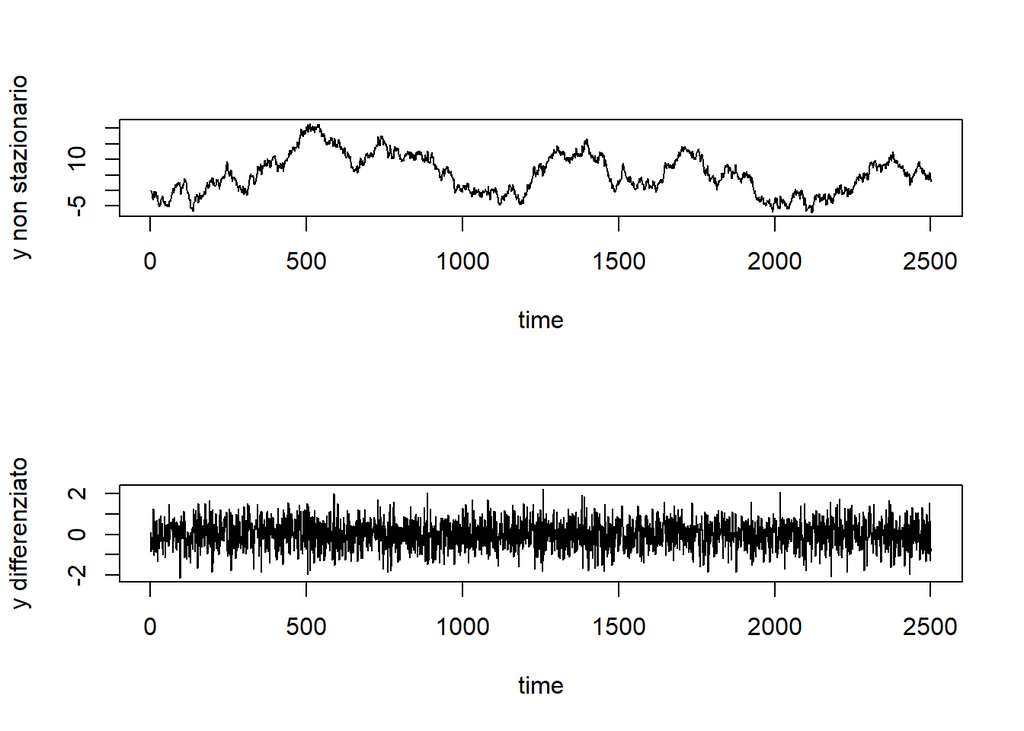

```r
y_diff=diff(y)

op=par(mfrow=c(2,1))
plot(y,xlab="time", ylab="y non stazionario")
plot(y_diff,xlab="time", ylab="y differenziato")
```

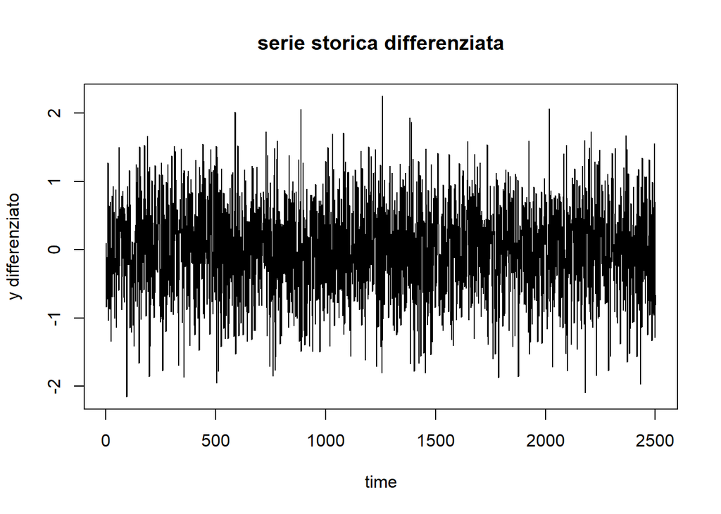

```r
plot(y_diff, main="serie storica differenziata", xlab="time", ylab="y differenziato")
```

Ora l’andamento del grafico sembra essere stazionario, rispetto all’originario. Sembra avere un valore medio vicino allo 0.

```r
round(basicStats(y_diff),digits=3)
```

```
##               y_diff
## nobs        2500.000
## NAs            0.000
## Minimum       -2.158
## Maximum        2.251
## 1. Quartile   -0.461
## 3. Quartile    0.464
## Mean           0.001
## Median         0.025
## Sum            3.026
## SE Mean        0.014
## LCL Mean      -0.025
## UCL Mean       0.028
## Variance       0.458
## Stdev          0.677
## Skewness      -0.089
## Kurtosis      -0.122
```

Una volta fatto ciò cerchiamo di capire, se quel problema di incertezza nell’evidenza empirica visto prima, adesso, si è risolto.

Guardando all’andamento della serie possiamo passare anche direttamente al test senza costante e trend:

```r
summary(ur.df(y = y_diff, type = 'none', selectlags = 'AIC'))
```

```
##
## ###############################################
## # Augmented Dickey-Fuller Test Unit Root Test #
## ###############################################
##
## Test regression none
##
##
## Call:
## lm(formula = z.diff ~ z.lag.1 - 1 + z.diff.lag)
##
## Residuals:
##      Min       1Q   Median       3Q      Max
## -2.24332 -0.42564  0.00718  0.43037  1.99376
##
## Coefficients:
##            Estimate Std. Error t value Pr(>|t|)
## z.lag.1    -1.07409    0.02389  -44.96   <2e-16 ***
## z.diff.lag  0.33701    0.01885   17.88   <2e-16 ***
## ---
## Signif. codes:  0 '***' 0.001 '**' 0.01 '*' 0.05 '.' 0.1 ' ' 1
##
## Residual standard error: 0.6247 on 2496 degrees of freedom
## Multiple R-squared:  0.4696, Adjusted R-squared:  0.4692
## F-statistic:  1105 on 2 and 2496 DF,  p-value: < 2.2e-16
##
##
## Value of test-statistic is: -44.9561
##
## Critical values for test statistics:
##       1pct  5pct 10pct
## tau1 -2.58 -1.95 -1.62
```

Il processo pò essere considerato stazionario, secondo il risultato del test, poiché, qualsiasi sia il livello di significatività considerato, abbiamo sempre evidenza empirica **contro** l’ipotesi H0: di assenza di stazionarietà e unit root.

## Stagionalità:

Vediamo ora se c’è ancora autocorrelazione, e se abbiamo stagionalità:

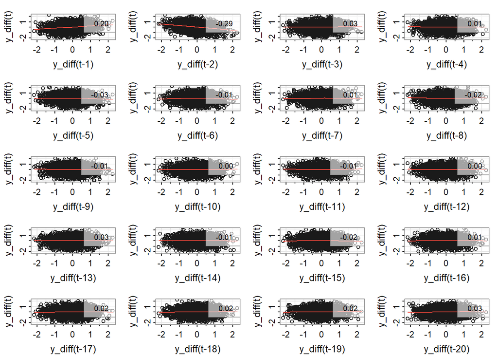

```r
lag1.plot(y_diff, 20)
```

l’autocorrelazione adesso è per ogni lag molto vicina allo 0, tranne per i primi due grafici dei ritardi 1 e 2, e non c’è alcuna stagionalità evidenziata dai grafici. Se ci fosse stata a cadenze regolari avremmo avuto un’autocorrelazione più elevata.

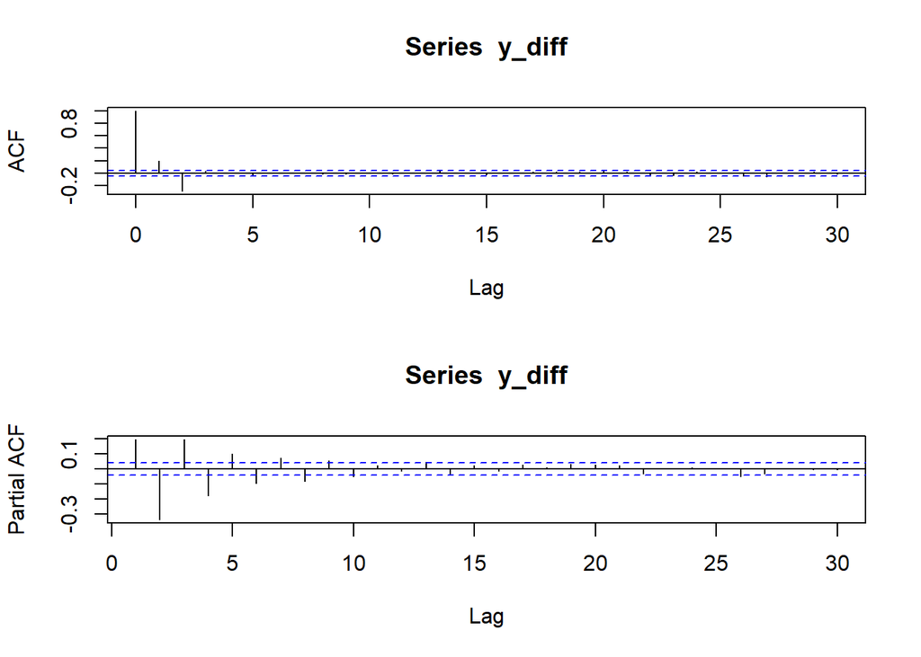

```r
op=par(mfrow=c(2,1))
acf(y_diff,lag.max=30)
pacf(y_diff,lag.max=30)
```

Dai correlogrammi non sembra esserci alcuna stagionalità, poiché a cadenze regolari non abbiamo alcuni picchi di autocorrelazione.

Verifichiamo se ci sono degli outliers:

```r
outliers_list = tsoutliers(y_diff)
outliers_list
```

```
## $index
## integer(0)
##
## $replacements
## numeric(0)
```

***non sono presenti outliers**

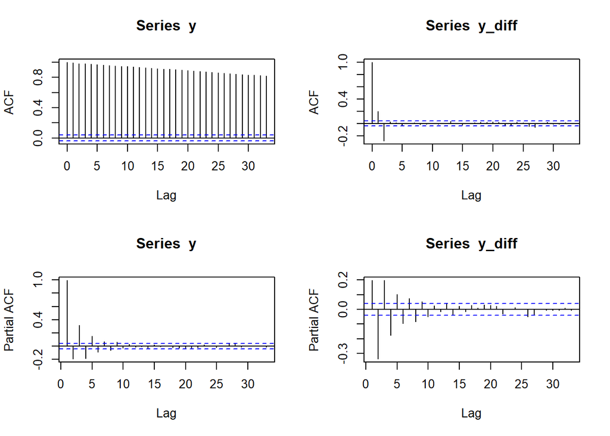

```r
op=par(mfcol=c(2,2))
acf(y)
pacf(y)
acf(y_diff)
pacf(y_diff)
```

Nella serie differenziata, notiamo come la ACF sia significativa per il 2^ ritardo (e diminuisce in valore assoluto anche se assumendo dei valori non statisticamente significativi), mentre la PACF è significativa nei primi ritardi e poi dimininuisce in valore assoluto. Si potrebbe ipotizzare un modello MA(2) oppure un ARMA(p,0,2), poiché non abbiamo una ACF che dopo il 2^ ritardo si annulla completamente diventando pari a zero, come vorrebbe la teoria.

## Stima del modello:

```r
arima_fit = auto.arima(y_diff, max.p = 10, max.q = 2, ic = "aic", seasonal = FALSE)
arima_fit
```

```
## Series: y_diff
## ARIMA(2,0,2) with zero mean
##
## Coefficients:
##           ar1      ar2     ma1      ma2
##       -0.1280  -0.0812  0.5460  -0.2356
## s.e.   0.1167   0.0590  0.1166   0.1057
##
## sigma^2 = 0.349:  log likelihood = -2230.02
## AIC=4470.03   AICc=4470.05   BIC=4499.15
```

T-test per valutare la significatività statistica dei parametri:

```r
t_stat <- (arima_fit$coef)/sqrt(diag(arima_fit$var.coef))
t_stat
```

```
##       ar1       ar2       ma1       ma2
## -1.096517 -1.376498  4.684188 -2.228661
```

in questo caso notiamo come i primi due coefficienti per un livello di significatività del 5% non sono statisticamente significativi poiché minori del valore assoluto di 1.96. Proviamo a vedere se con un altro criterio il risultato ottenuto è lo stesso.

Utiliziamo *il criterio di informazione Bayesiano,* che sappiamo essere maggiore di AIC per via della sua stessa formulazione.

Ci aspettiamo di trovare un modello più parsimonioso, poiché il modello BIC penalizza maggiormente il numero dei parametri stimati.

```r
arima_fit2 = auto.arima(y_diff, max.p = 10, max.q = 3, ic = "bic", seasonal = FALSE, approximation = TRUE)
arima_fit2
```

```
## Series: y_diff
## ARIMA(0,0,2) with zero mean
##
## Coefficients:
##          ma1      ma2
##       0.4168  -0.3613
## s.e.  0.0186   0.0185
##
## sigma^2 = 0.349:  log likelihood = -2230.91
## AIC=4467.82   AICc=4467.83   BIC=4485.3
```

In questo caso come output viene consigliato un altro modello MA(2),svolgiamo il t-test, per verificarne la significatività statistica.

```r
t_stat<-(arima_fit2$coef)/sqrt(diag(arima_fit2$var.coef))
t_stat
```

```
##       ma1       ma2
##  22.41652 -19.55002
```

in questo caso sono entrambi statisticamente diversi da 0 anche per un livello di significatività dell’1%.

Cambiando il criterio vengano stimati due modelli diversi, questo perchè è un caso limite. Continuiamo ad analizzare entrambi modelli per capire se c’è una differenza significativa dei risultati.

## Analisi dei residui:

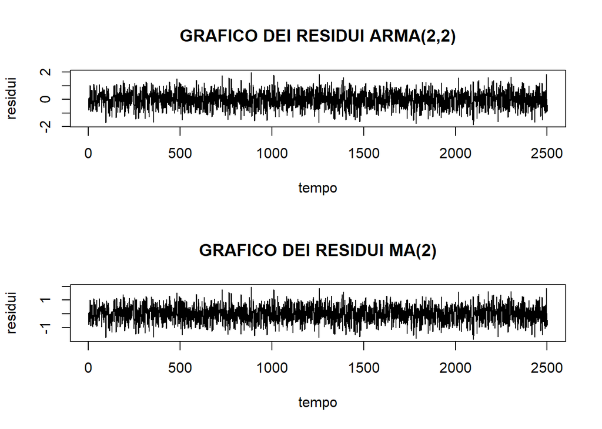

```r
res1=arima_fit$residuals
res2=arima_fit2$residuals

op=par(mfrow=c(2,1))
plot(res1,ylab="residui", xlab="tempo", main= "GRAFICO DEI RESIDUI ARMA(2,2)")
plot(res2,ylab="residui", xlab="tempo", main= "GRAFICO DEI RESIDUI MA(2)")
```

Dal grafico sembra che i residui non seguano un pattern specifico.

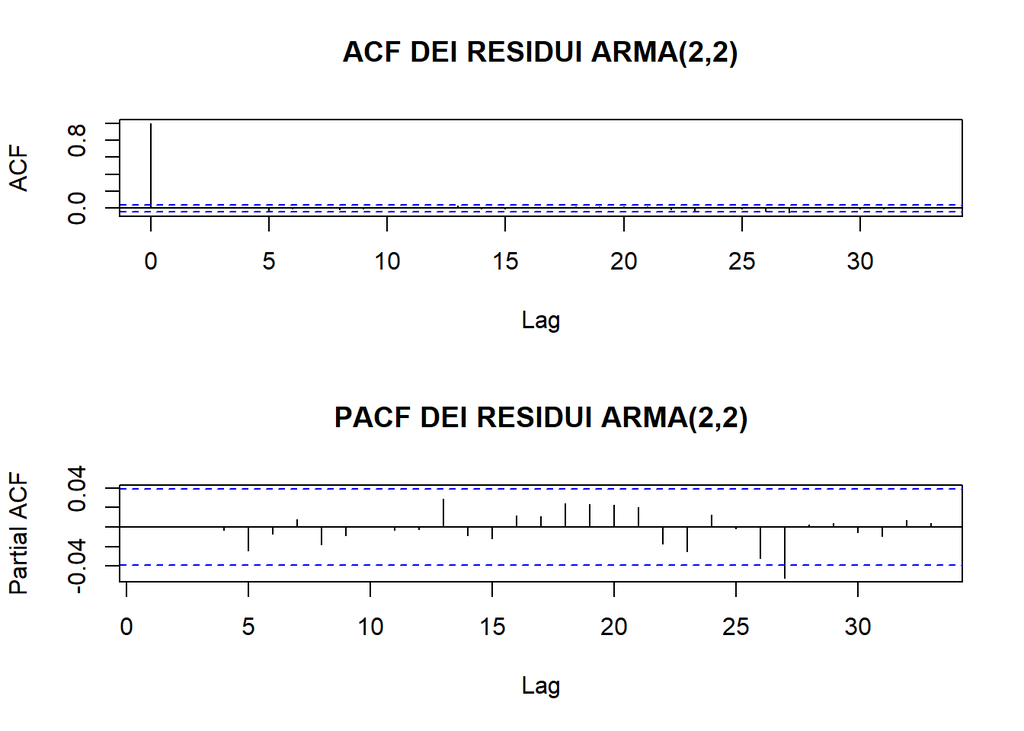

```r
op=par(mfcol=c(2,1))
acf(res1, main="ACF DEI RESIDUI ARMA(2,2)")
pacf(res1, main="PACF DEI RESIDUI ARMA(2,2)")
```

Non sembra quindi esserci autocorrelazione.

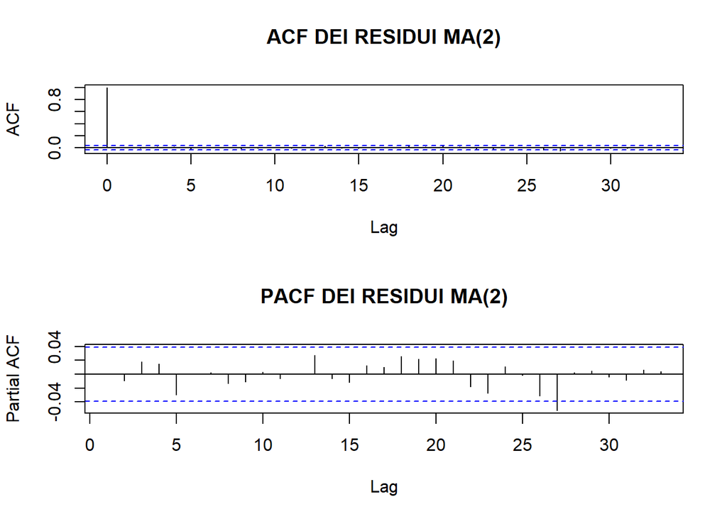

```r
op=par(mfcol=c(2,1))
acf(res2, main="ACF DEI RESIDUI MA(2)")
pacf(res2, main="PACF DEI RESIDUI MA(2)")
```

Otteniamo lo stesso risultato ottenuto sopra per il modello ARMA(2,2).

Ljung-Box test **ARMA(2,2):**

```r
Box.test(res1, lag=30, type="L", fitdf = 4)
```

```
##
##  Box-Ljung test
##
## data:  res1
## X-squared = 23.583, df = 26, p-value = 0.5998
```

L’ipotesi H0 del test non viene respinta, quindi si può pensare a un’indipendenza dei residui.

Ljung-Box test **MA(2):**

```r
Box.test(res2, lag=30, type="L", fitdf = 4)
```

```
##
##  Box-Ljung test
##
## data:  res2
## X-squared = 26.006, df = 26, p-value = 0.4628
```

Calcolo grafici di autocorrelazione del primo modello **Arma(2,2):**

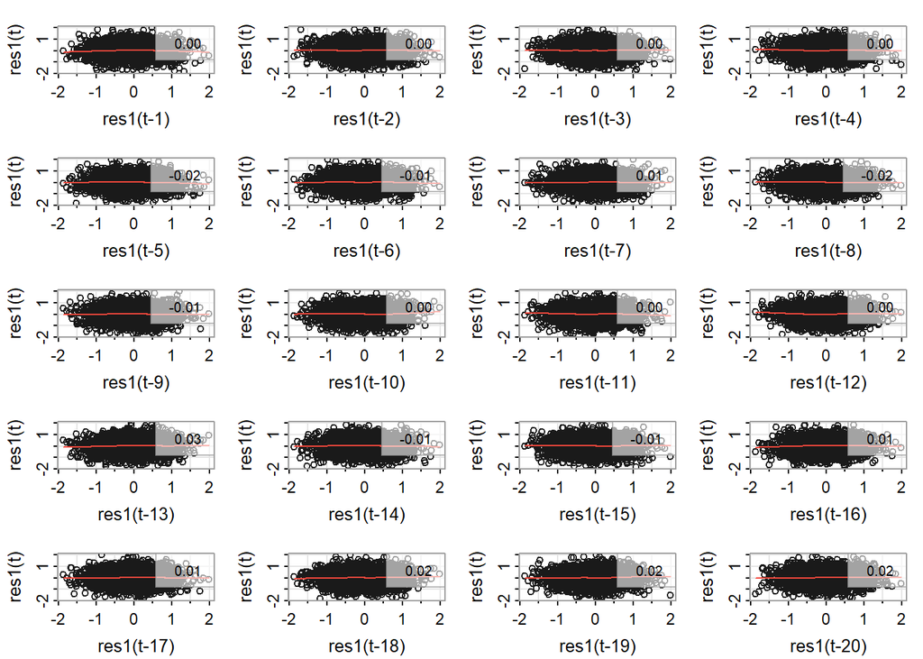

```r
lag1.plot(res1, max.lag=20)
```

Calcolo grafici di autocorrelazione del secondo modello **Ma(2):**

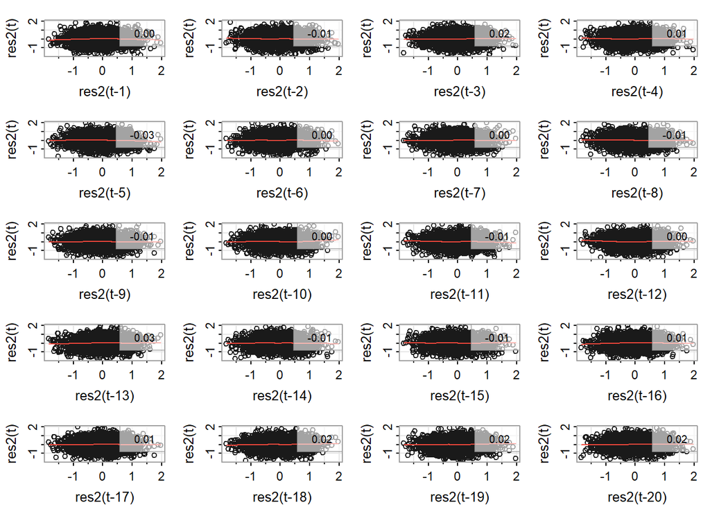

```r
lag1.plot(res2, max.lag=20)
```

non c’è autocorrelazione dei residui per entrambi i modelli.

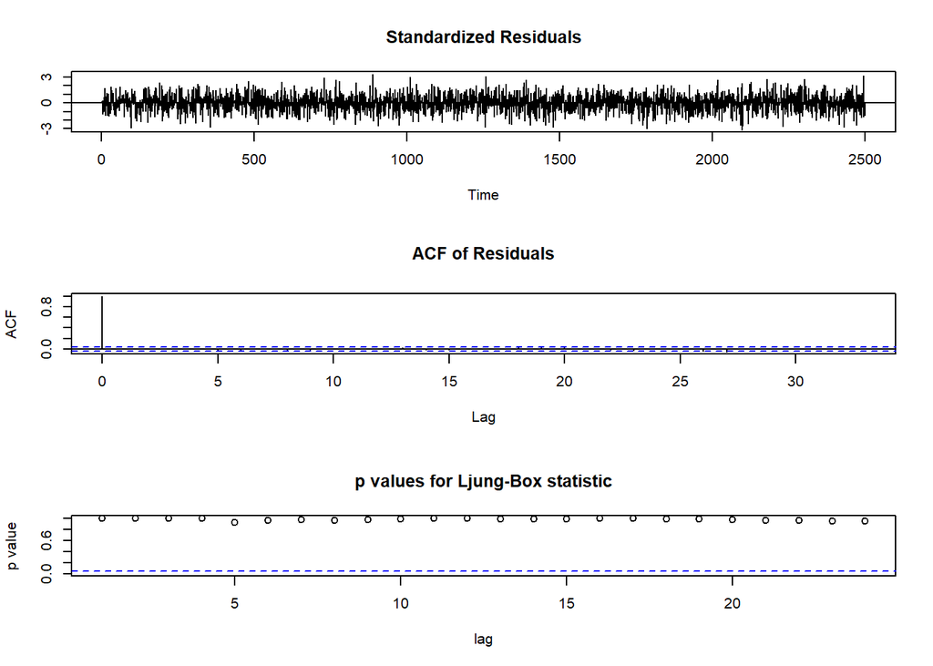

```r
tsdiag(arima_fit,gof.lag=24)
```

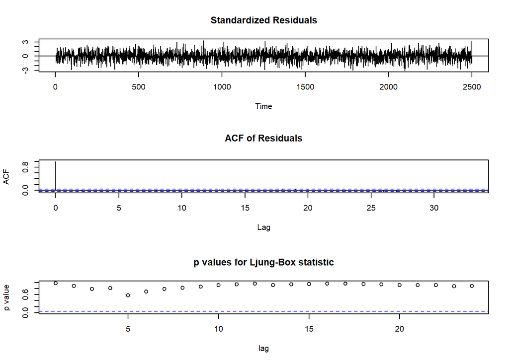

```r
tsdiag(arima_fit2,gof.lag=24)
```

guardando ai p-values si nota come i risultati ottenuti sopra dai grafici, qui vengono confermati.

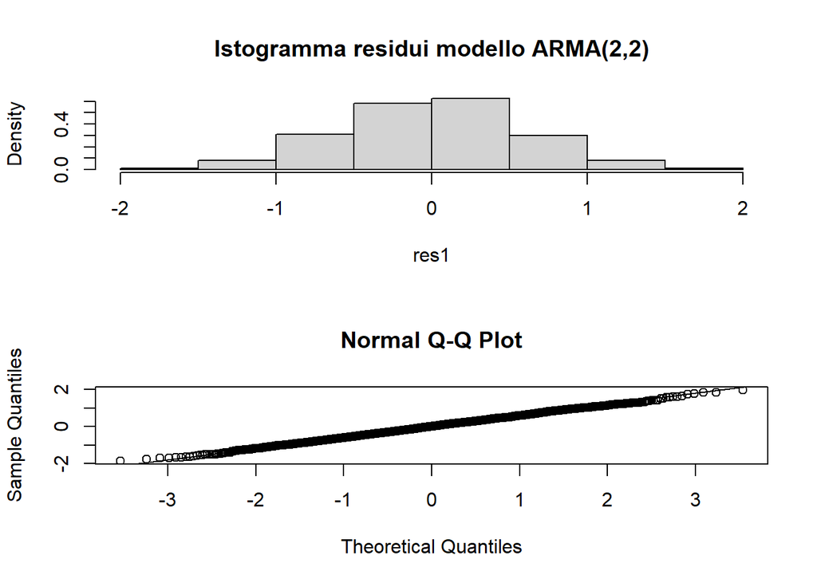

```r
op=par(mfrow=c(2,1))
hist(res1, freq=F, main="Istogramma residui modello ARMA(2,2)")
qqnorm(res1)
qqline(res1)
```

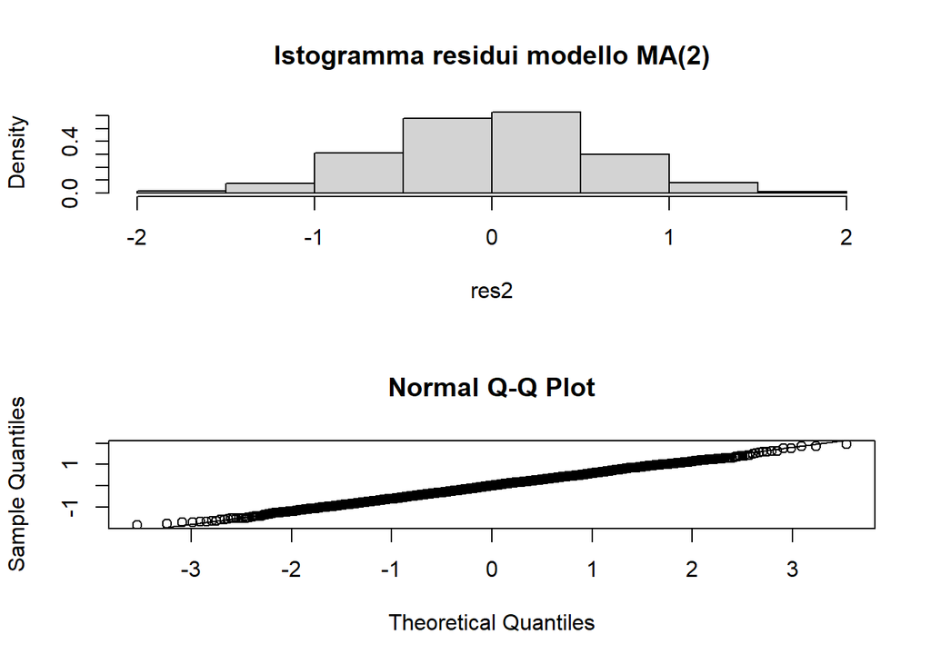

```r
op=par(mfrow=c(2,1))
hist(res2, freq=F,main="Istogramma residui modello MA(2)")
qqnorm(res2)
qqline(res2)
```

```r
jarque.bera.test(res1)
```

```
##
##  Jarque Bera Test
##
## data:  res1
## X-squared = 2.725, df = 2, p-value = 0.256
```

```r
jarque.bera.test(res2)
```

```
##
##  Jarque Bera Test
##
## data:  res2
## X-squared = 2.6915, df = 2, p-value = 0.2603
```

Si può pensare che siano entrambi distribuiti secondo una distribuzione normale.